# Introduction to remiod

**remiod** is acronymed from REference-based Multiple Imputation of Ordinal or Binary variables (Wang and Liu 2022). The purpose of the package is to facilitate the implementation of sensitivity analyses to ordinal/binary response variable with missingness.

Missing data are common in randomised controlled trials (RCTs) and can bias results if not handled appropriately. A statistically valid analysis under the primary missing-data assumptions, usually missing at random (MAR), can be planned, followed by sensitivity analyses under alternative justified assumptions to assess the robustness of results. Reference-based Multiple Imputation (MI) and delta adjustment procedures thus have been developed for analysis under missing-not-at-random (MNAR) assumptions.Tools in this package are developed specifically for reference-based analyses of binary or ordinal responses.

In this vignette, we use the `Schizophrenia` data which is a part of the **remiod** package. For more info on this data set, check the help file or visit the following [`link`](https://hedeker.people.uic.edu/ml.html). The original data is in a long format from a clinical trial, i.e. one row per patient per visit. We first reshape it into a wide format.

```r
data(schizo)

schizow = dcast(schizo, id + tx ~ week, value.var = "imps79o")
colnames(schizow) = c(colnames(schizow)[1:2], paste0("y",colnames(schizow)[-c(1:2)]))

schizow[,colnames(schizow)[-c(1:2)]] = lapply(schizow[,colnames(schizow)[-c(1:2)]],
                                              function(x) factor(x, levels = c("1", "2", "3", "4"), ordered=TRUE))

head(schizow)
```

```
#>     id tx y0 y1   y2 y3   y4   y5   y6
#> 1 1103  1  4  2 <NA>  2 <NA> <NA>    2
#> 2 1104  1  4  2 <NA>  1 <NA> <NA>    2
#> 3 1105  1  2  2 <NA>  1 <NA> <NA> <NA>
#> 4 1106  1  2  1 <NA>  1 <NA> <NA>    1
#> 5 1107  0  3  3 <NA>  3 <NA> <NA>    4
#> 6 1108  1  4  4 <NA>  2 <NA> <NA>    3
```

`tx` is the treatment variable with 1 being treated and 0 being placebo. `y0`,`y1`,…,`y6` are the response variables from baseline (visit=0) to visit 6. First, we check the missing pattern of variables in this data using function `md_pattern` from `JointAI`.

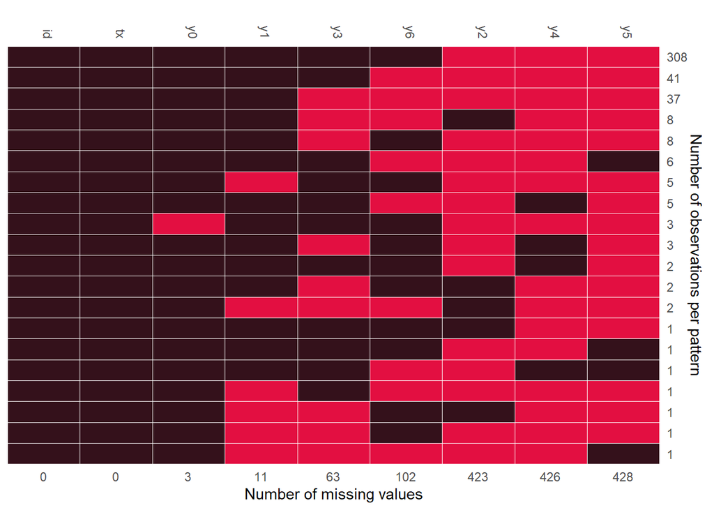

Figure 1: Missing pattern of Schizophrenia data

Figure 1 indicates there were missing values on the response variable at each visit from the baseline to the last visit. Applying sequential modeling method described by Tang (Tang 2018), `remiod` function can be set up as follows:

```r
test = remiod(formula = y6 ~ tx + y0 + y1 + y2 + y3 + y4 + y5, data=schizow,
              trtvar = 'tx', algorithm = "jags", method = "MAR",
              n.iter = 0, warn = FALSE, mess = FALSE)
list.models(test)
```

```
#>   Order model_formula
#> 1 1     y0 ~ tx
#> 2 2     y1 ~ tx + y0
#> 3 3     y3 ~ tx + y0 + y1
#> 4 4     y2 ~ tx + y0 + y1 + y3
#> 5 5     y4 ~ tx + y0 + y1 + y2 + y3
#> 6 6     y5 ~ tx + y0 + y1 + y2 + y3 + y4
#> 7 7     y6 ~ tx + y0 + y1 + y2 + y3 + y4 + y5
```

In the default setting, the sequence of models are ordered based on the number of missingness on each variables, which leads to the model on `y3` (the number of missing values is 63 as showed in Figure 1) preceding to the model on `y2` (the number of missing values is 423 as showed in Figure 1). In case the sequence of models is expected to follow time order of visits, option `model_order = paste0("y",0:5)` can be added to specify the model order as `y0`, `y1`, `y2`, `y3`, `y4`, and `y5`, for example:

```r
test_ord = remiod(formula = y6 ~ tx + y0 + y1 + y2 + y3 + y4 + y5, data=schizow,
                  trtvar = 'tx', algorithm = "jags", model_order = paste0("y",0:5),
                  method = "MAR", n.iter = 0, warn = FALSE, mess = FALSE)
list.models(test_ord)
```

```
#>   Order model_formula
#> 1 1     y0 ~ tx
#> 2 2     y1 ~ tx + y0
#> 3 3     y2 ~ tx + y0 + y1
#> 4 4     y3 ~ tx + y0 + y1 + y2
#> 5 5     y4 ~ tx + y0 + y1 + y2 + y3
#> 6 6     y5 ~ tx + y0 + y1 + y2 + y3 + y4
#> 7 7     y6 ~ tx + y0 + y1 + y2 + y3 + y4 + y5
```

Argument `method` in `remiod` function is the place to request controlled multiple imputation. `method = "MAR"` in the example setting above will give imputation based on MAR assumption. Other options include `J2R` (Jump to Reference), `CR` (Copy Reference), and `delta` (delta adjustment).Theoretic aspects of these methods can be found in Tang (2018).

```r
test_j2r = remiod(formula = y6 ~ tx + y0 + y1 + y3, data = schizow, trtvar = 'tx',
                  algorithm = "jags", method = "J2R", ord_cov_dummy = F,
                  n.iter = 20, n.adapt = 10, n.chains = 2, warn = FALSE, mess = FALSE)
names(test_j2r)
```

```
#> [1] "mc.mar"     "mi.setting" "mi.data"
```

```r
extdt = extract_MIdata(object=test_j2r, method="J2R",mi.setting=NULL, M=10, minspace=2)
table(extdt$Imp_)
```

```
#>
#>   1   2   3   4   5   6   7   8   9  10
#> 437 437 437 437 437 437 437 437 437 437
```

## References

Erler, NS, D Rizopoulos, and EMEH Lesaffre. 2021. “JointAI: Joint Analysis and Imputation of Incomplete Data in R.” *Journal of Statistical Software* 100 (20): 1–56.

Tang, Y. 2018. “Controlled Pattern Imputation for Sensitivity Analysis of Longitudinal Binary and Ordinal Outcomes with Nonignorable Dropout.” *Statistics in Medicine* 37 (9): 1467–81.

Wang, T, and Y Liu. 2022. “Remiod: Reference-Based Controlled Multiple Imputation of Longitudinal Binary and Ordinal Outcomes with Non-Ignorable Missingness.” *arXiv 2203.02771*.